# group_assignmnet

## Project Summary

This project focused on developing an intelligent medical chatbot designed to assist doctors by summarizing patient complaints and medical histories. The motivation behind the project is to address the challenge of handling large volumes of patient data efficiently, reducing the time doctors spend manually reviewing patient notes, and improving the overall patient experience.

We implemented a Natural Language Processing pipeline using the T5 model to generate concise summaries of patient problems based on raw input text. The project involved fine-tuning the T5 transformer model on a medical dataset consisting of patient descriptions, complaints, and diagnostic notes. We worked with 250,000 patient descriptions so that the model could understand what patients want when they are sick. The chatbot takes in a patient's problem description, processes it, and returns a summary. Based on that summary, the model calls an API through Streamlit apps to help the patient understand what needs to be done.

This project not only gives patients suggestions but also stores their past information. In our body, one problem is often related to other problems. So, based on the patient's previous issues, the chatbot provides feedback. It not only helps the patient but also assists doctors by informing them of the patient's previous conditions. This comprehensive approach enhances the quality of care and enables more informed decision-making. The dataset we downloaded from Hugging Face and all the preprocessing we have done are saved in the below google drive link. If anyone is interested in working with this preprocessed data, they can simply download it from here.

**Google drive link** - https://drive.google.com/drive/folders/1v6KRSdGiOeqN2Slg9CyqTZWFc07XPNR2?usp=share_link **git_experiment_link** - https://github.com/Md-SadmanSakib/medical_chatbot.git

### 1.Import Necessary Packages

```python
import pandas as pd
import numpy as np
```

```python
import sys
print(sys.version)
```

```
3.11.10 (main, Sep  7 2024, 18:35:41) [GCC 11.4.0]
```

```python
import sentencepiece
print("SentencePiece version:", sentencepiece.__version__)
```

```
SentencePiece version: 0.2.0
```

```python
import streamlit
import transformers
import torch
import tqdm
import numpy
import requests
import pandas
import sklearn

print("Streamlit:", streamlit.__version__)
print("Transformers:", transformers.__version__)
print("Torch:", torch.__version__)
print("TQDM:", tqdm.__version__)
print("NumPy:", numpy.__version__)
print("Requests:", requests.__version__)
print("Pandas:", pandas.__version__)
print("Scikit-learn:", sklearn.__version__)
```

```
Streamlit: 1.39.0
Transformers: 4.45.2
Torch: 2.4.1+cu124
TQDM: 4.66.5
NumPy: 1.26.3
Requests: 2.32.3
Pandas: 2.2.3
Scikit-learn: 1.5.2
```

```python
import torch
print(torch.__version__)
```

```
2.4.1+cu124
```

```python
import nltk
nltk.download('punkt')
```

```
True
```

```python
import re
import nltk
import pandas as pd
import spacy
from nltk.corpus import stopwords
from nltk.stem import WordNetLemmatizer
```

```python
import notebook
print(notebook.__version__)
```

```
6.5.5
```

```python
import pandas as pd
import spacy
import nltk

# Checking versions
print(f"pandas version: {pd.__version__}")
print(f"spacy version: {spacy.__version__}")
print(f"nltk version: {nltk.__version__}")
```

```
pandas version: 2.2.3
spacy version: 3.8.2
nltk version: 3.9.1
```

```python
nltk.download('stopwords')
nltk.download('wordnet')
nltk.download('omw-1.4')
```

```
True
```

### 2.Loading The Dataset

The dataset contains description, patient, and doctor fields, where "patient" represents the patient's problem and "description" is a concise summary of that problem. The "doctor" field contains the doctor's suggestion. We aim to create a chatbot that will utilize the concise summaries we have generated by training on the patient data. In this system, the role of the doctor will be played by an API, allowing us to provide up-to-date medical advice based on the generated summaries.

This approach combines the power of our trained model for understanding and summarizing patient issues with the flexibility of an external API for medical recommendations. By doing so, we can create a more dynamic and potentially more accurate medical chatbot that can adapt to new medical information as it becomes available through the API.

```python
workspace/project /dialogues.parquet
```

[output not shown]

```python
import os
print(os.getcwd())
```

```
/workspace/project
```

```python
file_path_train = '/workspace/project/dialogues.parquet'
df = pd.read_parquet(file_path_train)
```

```python
pd.set_option('display.max_colwidth', None)
```

```python
df.shape
```

```
(256916, 3)
```

```python
df.head()
```

|  | Description | Patient | Doctor |
| --- | --- | --- | --- |
| 0 | Q. What does abutment of the nerve root mean? | Hi doctor,I am just wondering what is abutting and abutment of the nerve root means in a back issue. Please explain. What treatment is required for annular bulging and tear? | Hi. I have gone through your query with diligence and would like you to know that I am here to help you. For further information consult a neurologist online --> |
| 1 | Q. What should I do to reduce my weight gained due to genetic hypothyroidism? | Hi doctor, I am a 22-year-old female who was diagnosed with hypothyroidism (genetic) when I was 12. Over the past five years, I have become around 50 pounds overweight and all of my attempts to lose h… | Hi. You have really done well with the hypothyroidism problem. Your levels are normal with less medications which are very good. As it is genetically induced, it is very difficult to lose weight. My a… |
| 2 | Q. I have started to get lots of acne on my face, particularly on my forehead. Please help me. | Hi doctor! I used to have clear skin but since I moved to a new place, I started to have lots of acne on my face particularly on my forehead. I thought it would disappear once I went back home, but it… | Hi there Acne has multifactorial etiology. Only acne soap does not improve if ypu have grade 2 or more grade acne. You need to have oral and topical medications. This before writing medicines i need t… |
| 3 | Q. Why do I have uncomfortable feeling between the middle of my spine and left shoulder blade? | Hello doctor,I am having an uncomfortable feeling in between the middle of my spine and left shoulder blade. It seems to get stiff, and my bones pop a lot around there, and it is very uncomfortable to… | Hello. The popping and discomfort what you felt is either because of improper scapulothoracic mobility or may be due to facet joint irritation in the neck with intervertebral hypermobility. Which coul… |
| 4 | Q. My symptoms after intercourse threatns me even after having negative HIV result. Kindly help. | Hello doctor,Before two years had sex with a call girl in a dark location for about 10 to15 min. I did not eject, and I am sure that she did not eject as well (not 100 % sure). Do not know if the cond… | Hello. The HIV test uses a finger prick blood sample, with results given within 20 minutes, and is 99 % accurate at detecting any HIV exposure that may have occurred more than 12 weeks ago. However, i… |

```python
# Check the columns
print(df.columns)

# Check for missing values
print(df.isnull().sum())
```

```
Index(['Description', 'Patient', 'Doctor'], dtype='object')
Description    0
Patient        0
Doctor         0
dtype: int64
```

### 3.Text Pre-processing

#### 3.1 Text Cleaning

When working with a text dataset, the most important part is cleaning. The better the cleaning, the more effectively the model will be able to capture the text. In this text preprocessing step, I have gone through several text cleaning processes to get better outcomes from the patient features and the description features. Our approach is creating a better and more concise summarization, so we did not perform all hard cleaning of the dataset because we need to capture the meaning

#### 3.1a First stage of text cleaning

```python
import re
import pandas as pd
import spacy
from multiprocessing import cpu_count
import contractions

# Initialize SpaCy with only necessary components
nlp = spacy.load("en_core_web_sm", disable=["parser", "ner", "textcat"])

# Define custom stopwords
custom_stopwords = set([
    "the", "a", "an", "and", "or", "but", "in", "on", "at", "to", "for", "of", "with", "by"
])

# Combine with a subset of SpaCy's default stopwords
custom_stopwords = custom_stopwords.union({
    word for word in spacy.lang.en.stop_words.STOP_WORDS
    if len(word) < 3 or word in ["be", "been", "being", "have", "had", "has", "do", "does", "did", "will", "would", "shall", "should"]
})

# Compile regular expressions for performance
RE_SPECIAL_CHARS = re.compile(r"[^a-zA-Z0-9\s\-'.,?!]")
RE_EXTRA_SPACES = re.compile(r'\s+')

def expand_contractions(text):
    """Expand contractions in the given text using the contractions library."""
    return contractions.fix(text)

def preprocess_texts(texts):
    """
    Preprocess a list of texts by expanding contractions and removing special characters.
    """
    # Expand contractions
    texts = [expand_contractions(text) for text in texts]

    # Remove special characters except allowed punctuation
    texts = [RE_SPECIAL_CHARS.sub('', text) for text in texts]

    # Remove extra spaces
    texts = [RE_EXTRA_SPACES.sub(' ', text).strip() for text in texts]

    return texts

def tokenize_and_lemmatize(texts, nlp, custom_stopwords):
    """
    Tokenize and lemmatize a list of preprocessed texts using SpaCy's nlp.pipe.
    """
    cleaned_texts = []
    for doc in nlp.pipe(texts, batch_size=1000, n_process=cpu_count()-1):
        tokens = [
            token.lemma_ if token.lemma_ != "-PRON-" else token.text.lower()
            for token in doc
            if token.text.lower() not in custom_stopwords and not token.is_punct and not token.is_space
        ]
        cleaned_texts.append(' '.join(tokens))
    return cleaned_texts

def clean_column(df, column_name, new_column_name, nlp, custom_stopwords):
    """
    Clean a specific column in the dataframe and store the result in a new column.
    """
    # Preprocess texts
    preprocessed_texts = preprocess_texts(df[column_name].astype(str).tolist())

    # Tokenize and lemmatize
    cleaned_texts = tokenize_and_lemmatize(preprocessed_texts, nlp, custom_stopwords)

    # Assign to new column
    df[new_column_name] = cleaned_texts
    return df

# Apply cleaning to 'Patient' and 'Description' columns
df = clean_column(df, 'Patient', 'patient_clean', nlp, custom_stopwords)
df = clean_column(df, 'Description', 'description_clean', nlp, custom_stopwords)

# remove the description that start with q
df['description_clean'] = df['description_clean'].apply(lambda x: x[2:] if x.startswith('q ') else x)

# Display the cleaned data
print(df[['Patient', 'patient_clean', 'Description', 'description_clean']].head())
```

```
                                                                                                                                                                                                                                                                                                            …
0                                                                                                                                                                                                                                                                                                           …
1                                                                                                                                                                                                                                                                                                           …
2                                                                                                                                                                                                                                                                                                           …
3                                                                                                                                                                                                                                                                                                           …
4  Hello doctor,Before two years had sex with a call girl in a dark location for about 10 to15 min. I did not eject, and I am sure that she did not eject as well (not 100 % sure). Do not know if the condom broke (as it was dark) but had some liquid on my penis (maybe fluid in condom, not sure) After…

                                                                                                                                                                                                                                                                                                            …
0                                                                                                                                                                                                                                                                                                           …
1                                                                                                                                                                                                                                                                                                           …
2                                                                                                                                                                                                                                                                                                           …
3                                                                                                                                                                                                                                                                                                           …
4  hello doctor before two year sex call girl dark location about 10 to15 min not eject sure that she not eject well not 100 sure not know condom break be dark some liquid penis maybe fluid condom not sure after few day from then cold follow itchy skin take medicine from doctor get resolve after few…

                                                                                        Description  \
0                                                     Q. What does abutment of the nerve root mean?
1                     Q. What should I do to reduce my weight gained due to genetic hypothyroidism?
2    Q. I have started to get lots of acne on my face, particularly on my forehead. Please help me.
3    Q. Why do I have uncomfortable feeling between the middle of my spine and left shoulder blade?
4  Q. My symptoms after intercourse threatns me even after having negative HIV result. Kindly help.

                                                                       description_clean
0                                                       q. what abutment nerve root mean
1                                  q. what reduce weight gain due genetic hypothyroidism
2                           Q. start get lot acne face particularly forehead please help
3                 q. why uncomfortable feeling between middle spine leave shoulder blade
4  Q. symptom after intercourse threatns even after have negative HIV result kindly help
```

#### 3.1b Second stage of text cleaning

```python
import re
import pandas as pd
import contractions

def clean_text_second_pass(text):
    # Expand contractions
    text = contractions.fix(text)

    # Remove 'Q.' and 'q.' at the beginning of the text
    text = re.sub(r'^[Qq]\.\s*', '', text)

    # Convert to lowercase
    text = text.lower()

    # Remove special characters except periods, commas, hyphens, and apostrophes
    text = re.sub(r'[^a-z0-9\s.,\'\-]', '', text)

    # Replace multiple spaces with a single space
    text = re.sub(r'\s+', ' ', text).strip()

    # Preserve common medical abbreviations and units
    text = re.sub(r'\b(hiv)\b', lambda m: m.group(0).upper(), text)

    return text

def clean_dataframe_second_pass(df):
    # Apply second pass cleaning to 'description_clean' column
    df['description_clean_2nd_pass'] = df['description_clean'].apply(clean_text_second_pass)

    # Apply second pass cleaning to 'patient_clean' column
    df['patient_clean_2nd_pass'] = df['patient_clean'].apply(clean_text_second_pass)

    return df


cleaned_df = clean_dataframe_second_pass(df)

# Display the first few rows of the cleaned dataframe
print(cleaned_df[['Description', 'description_clean', 'description_clean_2nd_pass']].head())
print("\n")
print(cleaned_df[['Patient', 'patient_clean', 'patient_clean_2nd_pass']].head())
```

```
                                                                                        Description  \
0                                                     Q. What does abutment of the nerve root mean?
1                     Q. What should I do to reduce my weight gained due to genetic hypothyroidism?
2    Q. I have started to get lots of acne on my face, particularly on my forehead. Please help me.
3    Q. Why do I have uncomfortable feeling between the middle of my spine and left shoulder blade?
4  Q. My symptoms after intercourse threatns me even after having negative HIV result. Kindly help.

                                                                       description_clean  \
0                                                       q. what abutment nerve root mean
1                                  q. what reduce weight gain due genetic hypothyroidism
2                           Q. start get lot acne face particularly forehead please help
3                 q. why uncomfortable feeling between middle spine leave shoulder blade
4  Q. symptom after intercourse threatns even after have negative HIV result kindly help

                                                           description_clean_2nd_pass
```

[output cut: 27 more lines]

#### 3.1c third stage of text cleaning

```python
import re

def clean_text_third_pass(text):
    # Capitalize first letter of sentences
    text = '. '.join(sentence.capitalize() for sentence in text.split('. '))

    # Preserve medical terms and units
    medical_terms = ['HIV', 'F', 'kg']
    for term in medical_terms:
        text = re.sub(r'\b' + term.lower() + r'\b', term, text)

    # Fix common grammatical issues
    text = re.sub(r'\bbe\b', 'is', text)
    text = re.sub(r'\bbecause\b', 'because', text)

    # Remove redundant words
    text = re.sub(r'\s+not\s+sure\b', '', text)

    # Fix number formatting
    text = re.sub(r'(\d+)\s*to\s*(\d+)', r'\1-\2', text)

    return text.strip()

def clean_dataframe_third_pass(df):
    df['patient_clean_3rd_pass'] = df['patient_clean_2nd_pass'].apply(clean_text_third_pass)
    return df

# Apply third pass cleaning
cleaned_df = clean_dataframe_third_pass(df)

# Display the results
print(cleaned_df[['patient_clean_2nd_pass', 'patient_clean_3rd_pass']].head())
```

```
                                                                                                                                                                                                                                                                                                            …
0                                                                                                                                                                                                                                                                                                           …
1                                                                                                                                                                                                                                                                                                           …
2                                                                                                                                                                                                                                                                                                           …
3                                                                                                                                                                                                                                                                                                           …
4  hello doctor before two year sex call girl dark location about 10 to15 min not eject sure that she not eject well not 100 sure not know condom break be dark some liquid penis maybe fluid condom not sure after few day from then cold follow itchy skin take medicine from doctor get resolve after few…

                                                                                                                                                                                                                                                                                                            …
0                                                                                                                                                                                                                                                                                                           …
1                                                                                                                                                                                                                                                                                                           …
2                                                                                                                                                                                                                                                                                                           …
3                                                                                                                                                                                                                                                                                                           …
4  Hello doctor before two year sex call girl dark location about 10-15 min not eject sure that she not eject well not 100 sure not know condom break is dark some liquid penis maybe fluid condom after few day from then cold follow itchy skin take medicine from doctor get resolve after few week from …
```

#### 3.1d Final stage of text cleaning

```python
import pandas as pd
import re

def clean_text_final_pass(text):
    # Capitalize first letter of sentences
    text = '. '.join(sentence.capitalize() for sentence in text.split('. '))

    # Fix common grammatical issues
    text = re.sub(r'\b(is|be|am|are|was|were)\b', 'is', text, flags=re.IGNORECASE)
    text = re.sub(r'\b(get|gets|getting)\b', 'gets', text, flags=re.IGNORECASE)
    text = re.sub(r'\b(feel|feels|feeling)\b', 'feels', text, flags=re.IGNORECASE)

    # Improve readability
    text = re.sub(r'(\d+)\s*(f|kg|min)\b', r'\1 \2', text, flags=re.IGNORECASE)
    text = re.sub(r'\s+', ' ', text).strip()  # Remove extra spaces

    # Fix specific phrases
    text = re.sub(r'\bthink\s+(?:is|am|are)\s+go(?:ing)?\s+(?:to)?\s+die\b', 'think I am going to die', text, flags=re.IGNORECASE)
    text = re.sub(r'\bwhat\s+(?:to)?\s*deal\b', 'what to deal with', text, flags=re.IGNORECASE)
    text = re.sub(r'\b(?:not|dont|don\'t)\s+know\b', 'do not know', text, flags=re.IGNORECASE)

    # Standardize medical terms
    text = re.sub(r'\bhiv\b', 'HIV', text, flags=re.IGNORECASE)

    return text

# Apply the final cleaning function to create a new column
try:
    df['patient_clean_final'] = df['patient_clean_3rd_pass'].apply(clean_text_final_pass)
    print("Final cleaning applied successfully.")

    # Display the first few rows of the DataFrame to compare
    print("\nSample results:")
    print(df[['patient_clean_3rd_pass', 'patient_clean_final']].head())

    # Print some statistics
    print(f"\nTotal rows processed: {len(df)}")
    print(f"Columns in DataFrame: {df.columns.tolist()}")

except Exception as e:
    print(f"An error occurred: {e}")
    print("Please check that your DataFrame and column names are correct.")
```

```
Final cleaning applied successfully.

Sample results:
                                                                                                                                                                                                                                                                                                            …
0                                                                                                                                                                                                                                                                                                           …
1                                                                                                                                                                                                                                                                                                           …
2                                                                                                                                                                                                                                                                                                           …
3                                                                                                                                                                                                                                                                                                           …
4  Hello doctor before two year sex call girl dark location about 10-15 min not eject sure that she not eject well not 100 sure not know condom break is dark some liquid penis maybe fluid condom after few day from then cold follow itchy skin take medicine from doctor get resolve after few week from …

                                                                                                                                                                                                                                                                                                            …
0                                                                                                                                                                                                                                                                                                           …
1                                                                                                                                                                                                                                                                                                           …
2                                                                                                                                                                                                                                                                                                           …
3                                                                                                                                                                                                                                                                                                           …
4  Hello doctor before two year sex call girl dark location about 10-15 min not eject sure that she not eject well not 100 sure do not know condom break is dark some liquid penis maybe fluid condom after few day from then cold follow itchy skin take medicine from doctor gets resolve after few week f…

Total rows processed: 256916
Columns in DataFrame: ['Description', 'Patient', 'Doctor', 'patient_clean', 'description_clean', 'description_clean_2nd_pass', 'patient_clean_2nd_pass', 'patient_clean_3rd_pass', 'patient_clean_final']
```

```python
import pandas as pd

# List of columns to keep
columns_to_keep = ['patient_clean_final', 'description_clean_2nd_pass', 'Doctor']

try:
    # Create a new DataFrame with only the specified columns
    df_filtered = df[columns_to_keep]

    print("DataFrame successfully filtered.")

    # Display information about the filtered DataFrame
    print("\nFiltered DataFrame Info:")
    print(df_filtered.info())

    # Display the first few rows of the filtered DataFrame
    print("\nFirst few rows of the filtered DataFrame:")
    print(df_filtered.head())

    # Verify the columns
    print("\nColumns in the filtered DataFrame:")
    print(df_filtered.columns.tolist())

except KeyError as e:
    print(f"Error: One of the specified columns does not exist in the DataFrame. Details: {e}")
except Exception as e:
    print(f"An unexpected error occurred: {e}")
```

```
DataFrame successfully filtered.

Filtered DataFrame Info:
<class 'pandas.core.frame.DataFrame'>
RangeIndex: 256916 entries, 0 to 256915
Data columns (total 3 columns):
 #   Column                      Non-Null Count   Dtype
---  ------                      --------------   -----
 0   patient_clean_final         256916 non-null  object
 1   description_clean_2nd_pass  256916 non-null  object
 2   Doctor                      256916 non-null  object
dtypes: object(3)
memory usage: 5.9+ MB
None

First few rows of the filtered DataFrame:
                                                                                                                                                                                                                                                                                                            …
0                                                                                                                                                                                                                                                                                                           …
1                                                                                                                                                                                                                                                                                                           …
2                                                                                                                                                                                                                                                                                                           …
3                                                                                                                                                                                                                                                                                                           …
4  Hello doctor before two year sex call girl dark location about 10-15 min not eject sure that she not eject well not 100 sure do not know condom break is dark some liquid penis maybe fluid condom after few day from then cold follow itchy skin take medicine from doctor gets resolve after few week f…

                                                           description_clean_2nd_pass  \
0                                                       what abutment nerve root mean
1                                  what reduce weight gain due genetic hypothyroidism
2                           start get lot acne face particularly forehead please help
3                 why uncomfortable feeling between middle spine leave shoulder blade
4  symptom after intercourse threatns even after have negative HIV result kindly help

                                                                                                                                                                                                                                                                                                            …
0                                                                                                                                                                                                                                                                                                           …
1  Hi. You have really done well with the hypothyroidism problem. Your levels are normal with less medications which are very good. As it is genetically induced, it is very difficult to lose weight. My advice to you is, you should focus on maintaining normal levels of TSH (thyroid-stimulating hormon…
2                                                                                                                                                                                                                                                                                                           …
3                                                                                                                                                                                                                                                                                                           …
4                                                                                                                                                                                                                                                                                                           …

Columns in the filtered DataFrame:
['patient_clean_final', 'description_clean_2nd_pass', 'Doctor']
```

#### 3.2 Tokenization

In this project, tokenization was primarily used for visualizing the patient descriptions being fed into the T5 model. Although the model handles tokenization internally during training, manually tokenizing the data allowed for better insight into the structure of the input, ensuring the data was appropriately prepared for the model.Before tokenizing both features, the dataframe was saved to track the dataset and the processes applied to it. The dataset has now been loaded from this newly saved file

```python
file_path_train_2 = '/workspace/project/renamed_filtered_patient_data.parquet'
df = pd.read_parquet(file_path_train_2)
```

```python
import re

def simple_tokenize(text):
    return re.findall(r'\b\w+\b', text.lower())

df['patient_tokens'] = df['patient_clean'].apply(simple_tokenize)
df['description_tokens'] = df['description_clean'].apply(simple_tokenize)
print(df[['patient_tokens', 'description_tokens']].head())
```

```
                                                                                                                                                                                                                                                                                                            …
0                                                                                                                                                                                                                                                                                                           …
1                                                                                                                                                                         [hi, doctor, 22, year, old, female, who, is, diagnose, hypothyroidism, genetic, when, is, 12, over, past, five, year, become, arou…
2                                                                                                                                                                                   [hi, doctor, use, clear, skin, since, move, new, place, start, lot, acne, face, particularly, forehead, think, disappear…
3  [hello, doctor, have, uncomfortable, feels, between, middle, spine, left, shoulder, blade, seem, gets, stiff, bone, pop, lot, around, there, very, uncomfortable, sit, specific, way, feels, like, bone, shift, well, other, night, seem, shoulder, pop, out, place, because, more, stiffness, after, whi…
4                  [hello, doctor, before, two, year, sex, call, girl, dark, location, about, 10, 15, min, not, eject, sure, that, she, not, eject, well, not, 100, sure, do, not, know, condom, break, is, dark, some, liquid, penis, maybe, fluid, condom, after, few, day, from, then, cold, follow, itch…

                                                                                description_tokens
0                                                              [what, abutment, nerve, root, mean]
1                                       [what, reduce, weight, gain, due, genetic, hypothyroidism]
2                              [start, get, lot, acne, face, particularly, forehead, please, help]
3                    [why, uncomfortable, feeling, between, middle, spine, leave, shoulder, blade]
4  [symptom, after, intercourse, threatns, even, after, have, negative, hiv, result, kindly, help]
```

```python
import re
from nltk.corpus import stopwords
import nltk
nltk.download('stopwords')

stop_words = set(stopwords.words('english')) - {'no', 'not'}

def preprocess_for_summarization(text):
    # Tokenize while keeping punctuation
    tokens = re.findall(r'\b[\w\']+\b|[.,!?;]', text.lower())
    # Remove stopwords and very short tokens
    tokens = [token for token in tokens if token not in stop_words and len(token) > 1]
    return tokens

df['processed_tokens'] = df['patient_clean'].apply(preprocess_for_summarization)
print(df[['processed_tokens']].head())
```

```
                                                                                                                                                                                                                                                                                                            …
0                                                                                                                                                                                                                                                                                                           …
1                                                                                                                                                                                                                                                                                   [hi, doctor, 22, year, o…
2                                                                                                                                                                                                                                                                                      [hi, doctor, use, cle…
3                                                                                                                                                                                       [hello, doctor, uncomfortable, feels, middle, spine, left, shoulder, blade, seem, gets, stiff, bone, pop, lot, aroun…
4  [hello, doctor, two, year, sex, call, girl, dark, location, 10, 15, min, not, eject, sure, not, eject, well, not, 100, sure, not, know, condom, break, dark, liquid, penis, maybe, fluid, condom, day, cold, follow, itchy, skin, take, medicine, doctor, gets, resolve, week, fever, 100, mild, night, s…
```

```python
df = df.drop('patient_tokens', axis=1)
```

```python
df = df.rename(columns={'processed_tokens': 'patient_tokens'})
```

```python
df = df.copy()
```

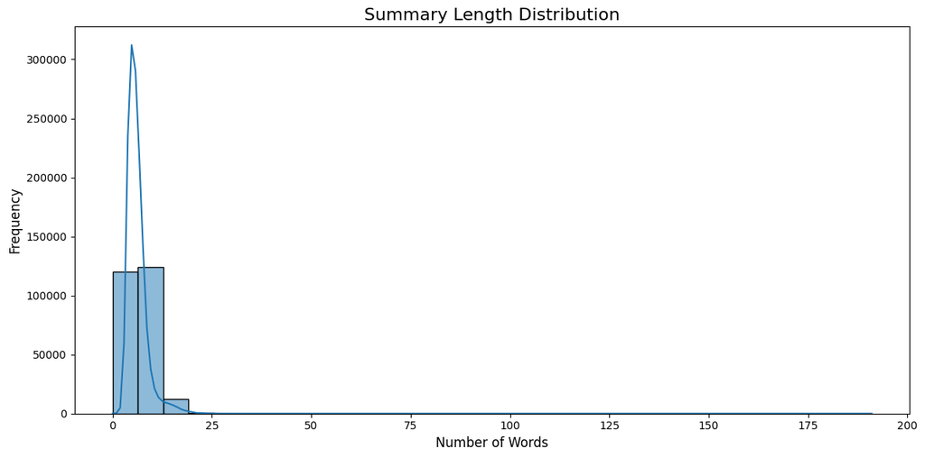

```
Most Common Words: [('is', 255843), ('not', 181701), ('that', 157292), ('this', 146695), ('pain', 127423), ('gets', 125568), ('day', 118628), ('she', 115629), ('year', 113470), ('take', 106660), ('doctor', 105846), ('what', 105189), ('can', 97829), ('now', 93053), ('feels', 89727), ('from', 79148), …
```

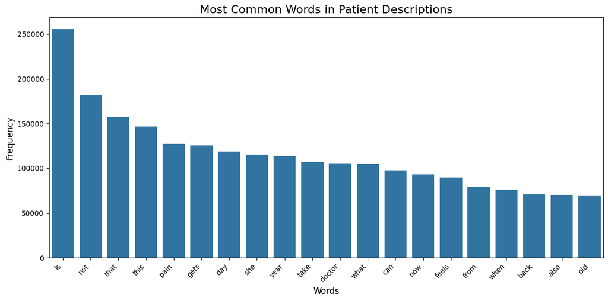

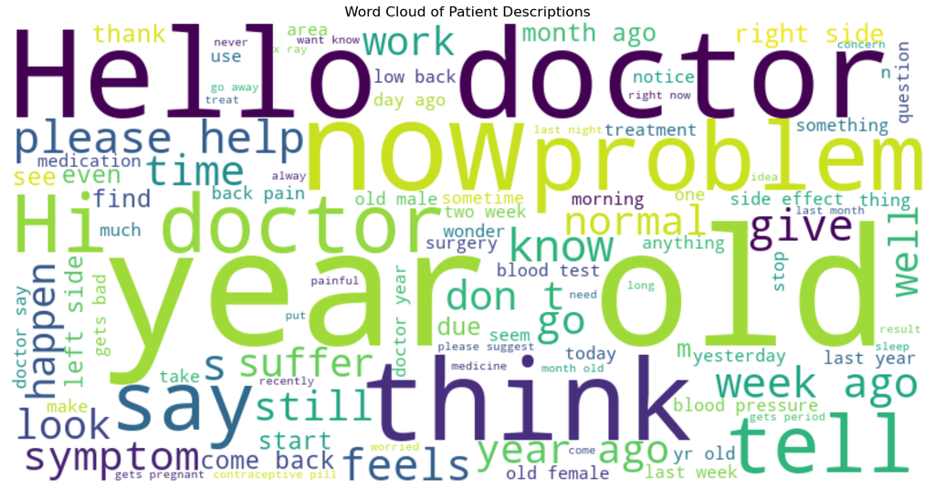

```python
import matplotlib.pyplot as plt
from collections import Counter
from wordcloud import WordCloud
import pandas as pd
import seaborn as sns



def plot_summary_length_distribution(df):
    df['summary_length'] = df['description_clean'].str.split().str.len()

    plt.figure(figsize=(12, 6))
    sns.histplot(data=df, x='summary_length', kde=True, bins=30)
    plt.title('Summary Length Distribution', fontsize=16)
    plt.xlabel('Number of Words', fontsize=12)
    plt.ylabel('Frequency', fontsize=12)
    plt.tight_layout()
    plt.show()

def get_common_words(df, column='patient_clean', n=20):
    all_words = ' '.join(df[column]).lower().split()
    return Counter(all_words).most_common(n)

def plot_common_words(common_words):
    words, counts = zip(*common_words)
    plt.figure(figsize=(12, 6))
    sns.barplot(x=list(words), y=list(counts))
    plt.title('Most Common Words in Patient Descriptions', fontsize=16)
    plt.xlabel('Words', fontsize=12)
    plt.ylabel('Frequency', fontsize=12)
    plt.xticks(rotation=45, ha='right')
    plt.tight_layout()
    plt.show()

def generate_wordcloud(df, column='patient_clean'):
    text = ' '.join(df[column])
    wordcloud = WordCloud(width=800, height=400, background_color='white',
                          max_words=100, contour_width=3, contour_color='steelblue')
    wordcloud.generate(text)

    plt.figure(figsize=(15, 7.5))
    plt.imshow(wordcloud, interpolation='bilinear')
    plt.axis('off')
    plt.title('Word Cloud of Patient Descriptions', fontsize=16)
    plt.tight_layout(pad=0)
    plt.show()

# Execute the functions
plot_summary_length_distribution(df)

common_words = get_common_words(df)
print("Most Common Words:", common_words)
plot_common_words(common_words)

generate_wordcloud(df)
```

**By looking at the patient talk, we can see that most discussions are about asking doctors about a variety of problems. It talks about symptoms, blood tests, treatment, suffering, and many other words that are related to the problems patients normally experience. They are also referring to their age and symptoms. Phrases like 'help,' 'please,' and 'give' also reflect that patients are seeking advice, diagnoses, or treatment solutions from their doctors**

```python
import nltk
from nltk.corpus import stopwords
from nltk.collocations import BigramAssocMeasures, BigramCollocationFinder

nltk.download('stopwords')

def get_meaningful_words(df, column='patient_clean', n=20):
    stop_words = set(stopwords.words('english'))
    all_words = ' '.join(df[column]).lower().split()
    meaningful_words = [word for word in all_words if word not in stop_words and len(word) > 2]
    return Counter(meaningful_words).most_common(n)

# Get meaningful words
meaningful_words = get_meaningful_words(df)
print("Most Meaningful Words:", meaningful_words)
```

```
Most Meaningful Words: [('pain', 127423), ('gets', 125568), ('day', 118628), ('year', 113470), ('take', 106660), ('doctor', 105846), ('feels', 89727), ('back', 71005), ('also', 70321), ('old', 69638), ('month', 69133), ('time', 68968), ('like', 66720), ('week', 64975), ('last', 60220), ('right', 511…
```

**In this step, stopword filtering was used to extract the most meaningful words from the patient descriptions. This allowed for a focus on words that provide the most insight into the common issues patients face, without eliminating them entirely. The most frequently occurring words, such as 'pain,' 'gets,' and 'doctor,' highlight what the patient suffers**

### 4.Data Preperation

After completing the text cleaning and tokenization, we will begin working on summarization. Before training, we have saved all the files so that when we need to run the code again, we don't have to repeat all the processing. This will save our time.For the summarization, we are using the t5-small transformer. Creating a summary and running it locally isn't the end goal. Pushing it one step further is necessary. Therefore, we used a lightweight transformer architecture so that we can use the saved model in production on a free tier version

```python
df.to_parquet('final_clean.parquet', index=False)
```

```python
import sys
print("Python executable being used:", sys.executable)
```

```
Python executable being used: /Applications/anaconda3/bin/python
```

```python
!{sys.executable} -m pip --version
```

```
pip 24.2 from /Applications/anaconda3/lib/python3.11/site-packages/pip (python 3.11)
```

```python
import sys
!{sys.executable} -m pip install --upgrade sentencepiece
```

```python
file_path_train_3 = '/workspace/project/final_clean.parquet'
df = pd.read_parquet(file_path_train_3)
```

```python
df.head()
```

|  | patient_clean | description_clean | Doctor | description_tokens | patient_tokens | summary_length |
| --- | --- | --- | --- | --- | --- | --- |
| 0 | Hi doctor just wonder what abut abutment nerve... | what abutment nerve root mean | Hi. I have gone through your query with dilige... | [what, abutment, nerve, root, mean] | [hi, doctor, wonder, abut, abutment, nerve, ro... | 5 |
| 1 | Hi doctor 22 year old female who is diagnose h... | what reduce weight gain due genetic hypothyroi... | Hi. You have really done well with the hypothy... | [what, reduce, weight, gain, due, genetic, hyp... | [hi, doctor, 22, year, old, female, diagnose, ... | 7 |
| 2 | Hi doctor use clear skin since move new place ... | start get lot acne face particularly forehead ... | Hi there Acne has multifactorial etiology. Onl... | [start, get, lot, acne, face, particularly, fo... | [hi, doctor, use, clear, skin, since, move, ne... | 9 |
| 3 | Hello doctor have uncomfortable feels between ... | why uncomfortable feeling between middle spine... | Hello. The popping and discomfort what you fel... | [why, uncomfortable, feeling, between, middle,... | [hello, doctor, uncomfortable, feels, middle, ... | 9 |
| 4 | Hello doctor before two year sex call girl dar... | symptom after intercourse threatns even after ... | Hello. The HIV test uses a finger prick blood ... | [symptom, after, intercourse, threatns, even, ... | [hello, doctor, two, year, sex, call, girl, da... | 12 |

```python
import sentencepiece
print("SentencePiece version:", sentencepiece.__version__)
```

```
SentencePiece version: 0.2.0
```

```python
import transformers
print(transformers.__version__)
```

```
4.45.2
```

```python
from transformers import T5Tokenizer
```

```python
import pandas as pd
from sklearn.model_selection import train_test_split
```

```python
# Check for missing values
print(df.isnull().sum())
```

```
patient_clean         0
description_clean     0
Doctor                0
description_tokens    0
patient_tokens        0
summary_length        0
dtype: int64
```

```python
import pandas as pd

# Check for duplicate rows based on both 'patience_clean' and 'description_clean'
duplicate_rows = df.duplicated(subset=['patient_clean', 'description_clean'], keep=False)
num_duplicates = duplicate_rows.sum()
print(f"Number of duplicate rows: {num_duplicates}")

# Remove duplicate rows
df = df.drop_duplicates(subset=['patient_clean', 'description_clean']).reset_index(drop=True)
print(f"Dataset size after removing duplicates: {len(df)}")
```

```
Number of duplicate rows: 10497
Dataset size after removing duplicates: 246493
```

```python
# Confirm no duplicates remain
duplicate_rows = df.duplicated(subset=['patient_clean', 'description_clean'], keep=False)
num_duplicates = duplicate_rows.sum()
print(f"Number of duplicate rows after cleaning: {num_duplicates}")
```

```
Number of duplicate rows after cleaning: 0
```

```python
# Define input and target columns
input_column = 'patient_clean'
target_column = 'description_clean'

# Extract the lists of inputs and targets
inputs = df[input_column].tolist()
targets = df[target_column].tolist()
```

```python
print(f"Total samples: {len(inputs)}")
```

```
Total samples: 246493
```

```python
df.shape
```

```
(246493, 6)
```

**the dataset was split into training (80%), validation (10%), and test (10%) sets to ensure a proper evaluation of the model’s performance**

```python
from sklearn.model_selection import train_test_split
import numpy as np

# Set a random seed for reproducibility
random_seed = 42
np.random.seed(random_seed)

# Total number of samples
total_samples = len(df)

# Create a list of indices and shuffle them
indices = np.arange(total_samples)
np.random.shuffle(indices)

# Define split sizes
train_size = int(0.80 * total_samples)  # 80% for training
val_size = int(0.10 * total_samples)    # 10% for validation
test_size = total_samples - train_size - val_size  # 10% for testing

print(f"Train size: {train_size}, Validation size: {val_size}, Test size: {test_size}")

# Split the indices
train_indices = indices[:train_size]
val_indices = indices[train_size:train_size + val_size]
test_indices = indices[train_size + val_size:]

# Assign data to splits based on indices
train_inputs = [inputs[i] for i in train_indices]
train_targets = [targets[i] for i in train_indices]

val_inputs = [inputs[i] for i in val_indices]
val_targets = [targets[i] for i in val_indices]

test_inputs = [inputs[i] for i in test_indices]
test_targets = [targets[i] for i in test_indices]
```

```
Train size: 197194, Validation size: 24649, Test size: 24650
```

```python
# Convert lists to sets to check for overlaps
train_set = set(train_indices)
val_set = set(val_indices)
test_set = set(test_indices)

print("Overlap between Training and Validation:", len(train_set.intersection(val_set)) > 0)
print("Overlap between Training and Testing:", len(train_set.intersection(test_set)) > 0)
print("Overlap between Validation and Testing:", len(val_set.intersection(test_set)) > 0)
```

```
Overlap between Training and Validation: False
Overlap between Training and Testing: False
Overlap between Validation and Testing: False
```

```python
# Define a function to format the data
def format_data(input_text, target_text):
    return "summarize: " + input_text, target_text

# Apply the formatting to each split
formatted_train_inputs = [format_data(inp, tgt) for inp, tgt in zip(train_inputs, train_targets)]
formatted_val_inputs = [format_data(inp, tgt) for inp, tgt in zip(val_inputs, val_targets)]
formatted_test_inputs = [format_data(inp, tgt) for inp, tgt in zip(test_inputs, test_targets)]
```

### 5.Model Training

```python
import torch
from torch.utils.data import Dataset
class SummarizationDataset(Dataset):
    def __init__(self, data, tokenizer, max_input_length=512, max_target_length=150):
        """
        Initializes the dataset with data and tokenizer.

        Args:
            data (list of tuples): List containing (input_text, target_text) pairs.
            tokenizer (transformers.PreTrainedTokenizer): Tokenizer for encoding the text.
            max_input_length (int, optional): Maximum length for input sequences.
            max_target_length (int, optional): Maximum length for target sequences.
        """
        self.data = data
        self.tokenizer = tokenizer
        self.max_input_length = max_input_length
        self.max_target_length = max_target_length

    def __len__(self):
        """
        Returns the total number of samples in the dataset.
        """
        return len(self.data)

    def __getitem__(self, index):
        """
        Retrieves the sample at the specified index.

        Args:
            index (int): Index of the sample to retrieve.

        Returns:
            dict: Dictionary containing input_ids, attention_mask, and labels tensors.
        """
        input_text, target_text = self.data[index]

        # Encode the inputs
        input_encoding = self.tokenizer.encode_plus(
            input_text,
            max_length=self.max_input_length,
            padding='max_length',
            truncation=True,
            return_attention_mask=True,
            return_tensors='pt'
        )

        # Encode the targets
        target_encoding = self.tokenizer.encode_plus(
            target_text,
            max_length=self.max_target_length,
            padding='max_length',
            truncation=True,
            return_attention_mask=True,
            return_tensors='pt'
        )

        return {
            'input_ids': input_encoding['input_ids'].flatten(),
            'attention_mask': input_encoding['attention_mask'].flatten(),
            'labels': target_encoding['input_ids'].flatten()
        }

# Initialize the tokenizer
model_name = 't5-small'
tokenizer = T5Tokenizer.from_pretrained(model_name)
```

```
You are using the default legacy behaviour of the <class 'transformers.models.t5.tokenization_t5.T5Tokenizer'>. This is expected, and simply means that the `legacy` (previous) behavior will be used so nothing changes for you. If you want to use the new behaviour, set `legacy=False`. This should only…
```

```python
# Create datasets
train_dataset = SummarizationDataset(formatted_train_inputs, tokenizer)
val_dataset = SummarizationDataset(formatted_val_inputs, tokenizer)
test_dataset = SummarizationDataset(formatted_test_inputs, tokenizer)
```

```python
from torch.utils.data import DataLoader

# Define batch size
batch_size = 32

# Number of workers for parallel data loading
num_workers = 32

# Create DataLoaders with optimized num_workers
train_loader = DataLoader(train_dataset, batch_size=batch_size, shuffle=True, num_workers=num_workers, pin_memory=True)
val_loader = DataLoader(val_dataset, batch_size=batch_size, num_workers=num_workers, pin_memory=True)
test_loader = DataLoader(test_dataset, batch_size=batch_size, num_workers=num_workers, pin_memory=True)

print(f"Using {num_workers} workers for data loading.")
```

```
Using 32 workers for data loading.
```

```python
import multiprocessing

# Get the number of available CPU cores
num_workers = multiprocessing.cpu_count()

print(f"Number of CPU cores available: {num_workers}")
```

```
Number of CPU cores available: 48
```

```python
import torch
from transformers import T5Tokenizer, T5ForConditionalGeneration, AdamW
from tqdm import tqdm
```

```python
import torch

# Check if CUDA is available and set the device
if torch.cuda.is_available():
    device = torch.device("cuda")
    print(f"CUDA device detected: {torch.cuda.get_device_name(0)}. Using CUDA for training.")
else:
    device = torch.device("cpu")
    print("No GPU detected. Using CPU for training.")

print(f"Training on device: {device}")
```

```
CUDA device detected: NVIDIA RTX 4000 Ada Generation. Using CUDA for training.
Training on device: cuda
```

```python
# Define the model name
model_name = 't5-small'

# Load the model
model = T5ForConditionalGeneration.from_pretrained(model_name)

# Move the model to the selected device
model = model.to(device)
```

```python
#print the device of the model
print(f"Model device: {model.device}")
```

```
Model device: cuda:0
```

**For this project, we used the AdamW optimizer, which performs better than Adam in this context, and selected a low learning rate to ensure proper convergence. Additionally, we applied early stopping to prevent overfitting and saved the best-performing model during training**

```python
from torch.optim import AdamW

# Define the optimizer
optimizer = AdamW(model.parameters(), lr=5e-5)
```

```python
from torch.utils.tensorboard import SummaryWriter

# Initialize TensorBoard writer
writer = SummaryWriter('runs/t5_training')

# Define Early Stopping parameters
best_val_loss = float('inf')
patience = 5  # Number of epochs to wait for improvement
trigger_times = 0

# Define the number of epochs
epochs = 10

for epoch in range(epochs):
    # ---------------------
    # Training Phase
    # ---------------------
    model.train()
    print(f"\nEpoch {epoch + 1}/{epochs}")
    epoch_loss = 0

    for batch in tqdm(train_loader, desc="Training"):
        # Move batch to the device
        input_ids = batch['input_ids'].to(device)
        attention_mask = batch['attention_mask'].to(device)
        labels = batch['labels'].to(device)

        # Clear gradients
        optimizer.zero_grad()

        # Forward pass
        outputs = model(input_ids=input_ids, attention_mask=attention_mask, labels=labels)
        loss = outputs.loss
        epoch_loss += loss.item()

        # Backward pass
        loss.backward()
        optimizer.step()

    # Calculate average training loss for the epoch
    avg_epoch_loss = epoch_loss / len(train_loader)
    print(f"Average Training Loss: {avg_epoch_loss:.4f}")

    # Log training loss to TensorBoard
    writer.add_scalar('Loss/Train', avg_epoch_loss, epoch)

    # ---------------------
    # Validation Phase
    # ---------------------
    model.eval()
    val_loss = 0

    with torch.no_grad():
        for batch in tqdm(val_loader, desc="Validation"):
            input_ids = batch['input_ids'].to(device)
            attention_mask = batch['attention_mask'].to(device)
            labels = batch['labels'].to(device)

            # Forward pass
            outputs = model(input_ids=input_ids, attention_mask=attention_mask, labels=labels)
            loss = outputs.loss
            val_loss += loss.item()

    # Calculate average validation loss for the epoch
    avg_val_loss = val_loss / len(val_loader)
    print(f"Average Validation Loss: {avg_val_loss:.4f}")

    # Log validation loss to TensorBoard
    writer.add_scalar('Loss/Validation', avg_val_loss, epoch)

    # ---------------------
    # Early Stopping Check
    # ---------------------
    if avg_val_loss < best_val_loss:
        best_val_loss = avg_val_loss
        trigger_times = 0
        # Save the best model
        model.save_pretrained("best_t5_model")
        tokenizer.save_pretrained("best_t5_model")
        print("Validation loss improved. Model saved.")
    else:
        trigger_times += 1
        print(f"EarlyStopping counter: {trigger_times} out of {patience}")
        if trigger_times >= patience:
            print("Early stopping triggered!")
            break

# Close TensorBoard writer
writer.close()
```

[output not shown]

```
Average Training Loss: 0.1563
```

```
Average Validation Loss: 0.1407
Validation loss improved. Model saved.
```

[output not shown]

```
Average Validation Loss: 0.1349
Validation loss improved. Model saved.
```

[output not shown]

[output not shown]

```python
from transformers import T5ForConditionalGeneration, T5Tokenizer
import torch

# Set device
device = torch.device("cuda" if torch.cuda.is_available() else "cpu")

# Load the model and tokenizer from the saved directory
model = T5ForConditionalGeneration.from_pretrained("best_t5_model")
tokenizer = T5Tokenizer.from_pretrained("best_t5_model")

# Move the model to the appropriate device
model.to(device)

print("Model and tokenizer reloaded successfully.")
```

```
Model and tokenizer reloaded successfully.
```

**The Best_T5 model was saved, run, and evaluated on the validation dataset**

```python
val_loss = 0
num_batches = 0

with torch.no_grad():
    for batch in val_loader:
        input_ids = batch['input_ids'].to(device)
        attention_mask = batch['attention_mask'].to(device)
        labels = batch['labels'].to(device)

        # Forward pass
        outputs = model(input_ids=input_ids, attention_mask=attention_mask, labels=labels)
        loss = outputs.loss
        val_loss += loss.item()
        num_batches += 1

avg_val_loss = val_loss / num_batches
print(f"Average Validation Loss: {avg_val_loss:.4f}")
```

```
Average Validation Loss: 0.1281
```

### 6.Model Evaluation

For evaluating the performance of our summarization model, we used the ROUGE metric, specifically ROUGE-1, ROUGE-2, and ROUGE-L. These metrics help us measure the overlap between the generated summaries and the reference summaries, capturing both unigram/bigram accuracy and overall fluency

```python
from rouge_score import rouge_scorer

# Initialize the ROUGE scorer
scorer = rouge_scorer.RougeScorer(['rouge1', 'rouge2', 'rougeL'], use_stemmer=True)
```

```python
from transformers import T5Tokenizer, T5ForConditionalGeneration
```

```python
from tqdm import tqdm
import logging

# Set up logging to a file to avoid overloading Jupyter output
logging.basicConfig(filename='summary_generation.log', level=logging.INFO)

def generate_summaries(model, tokenizer, dataloader, device, max_length=150, min_length=40):
    """
    Generates summaries for the given dataset.

    Args:
        model (transformers.PreTrainedModel): The trained model.
        tokenizer (transformers.PreTrainedTokenizer): The tokenizer.
        dataloader (DataLoader): DataLoader for the dataset.
        device (torch.device): Device to run the model on.
        max_length (int, optional): Maximum length of the generated summary.
        min_length (int, optional): Minimum length of the generated summary.

    Returns:
        list: Generated summaries.
        list: Reference summaries.
    """
    best_model.eval()
    summaries = []
    references = []

    with torch.no_grad():
        for i, batch in enumerate(tqdm(dataloader, desc="Generating Summaries", mininterval=10)):  # Reduce tqdm verbosity
            input_ids = batch['input_ids'].to(device)
            attention_mask = batch['attention_mask'].to(device)

            # Generate summaries
            generated_ids = model.generate(
                input_ids=input_ids,
                attention_mask=attention_mask,
                max_length=max_length,
                min_length=min_length,
                num_beams=4,
                early_stopping=True
            )

            # Decode summaries
            decoded_summaries = tokenizer.batch_decode(generated_ids, skip_special_tokens=True)
            summaries.extend(decoded_summaries)

            # Decode references without modifying labels
            labels = batch['labels']
            decoded_references = tokenizer.batch_decode(labels, skip_special_tokens=True)
            references.extend(decoded_references)

            # Log progress to avoid overwhelming Jupyter output
            logging.info(f"Batch {i+1}/{len(dataloader)} processed.")

    return summaries, references

# Generate summaries and references on the test set
test_summaries, test_references = generate_summaries(best_model, best_tokenizer, test_loader, device)
```

```python
from rouge_score import rouge_scorer
import numpy as np

def compute_rouge(predictions, references):
    """
    Computes average ROUGE scores between predictions and references.

    Args:
        predictions (list): Generated summaries.
        references (list): Reference summaries.

    Returns:
        dict: Average ROUGE-1, ROUGE-2, and ROUGE-L scores.
    """
    scorer = rouge_scorer.RougeScorer(['rouge1', 'rouge2', 'rougeL'], use_stemmer=True)
    scores = {'rouge1': [], 'rouge2': [], 'rougeL': []}

    for pred, ref in zip(predictions, references):
        score = scorer.score(ref, pred)
        scores['rouge1'].append(score['rouge1'].fmeasure)
        scores['rouge2'].append(score['rouge2'].fmeasure)
        scores['rougeL'].append(score['rougeL'].fmeasure)

    # Calculate average scores
    avg_scores = {metric: np.mean(values) for metric, values in scores.items()}
    return avg_scores

# Compute ROUGE scores
test_rouge_scores = compute_rouge(test_summaries, test_references)

# Display the scores
print("\nTest ROUGE Scores:")
for metric, score in test_rouge_scores.items():
    print(f"{metric}: {score:.4f}")
```

```
Test ROUGE Scores:
rouge1: 0.2676
rouge2: 0.1174
rougeL: 0.2367
```

```python
def display_samples(inputs, summaries, references, num_examples=3):
    """
    Displays sample inputs, reference summaries, and generated summaries.

    Args:
        inputs (list): List of input texts.
        summaries (list): List of generated summaries.
        references (list): List of reference summaries.
        num_examples (int, optional): Number of examples to display.
    """
    for i in range(num_examples):
        print(f"--- Example {i+1} ---")
        print(f"Input: {inputs[i]}")
        print(f"Reference Summary: {references[i]}")
        print(f"Model Summary: {summaries[i]}\n")

# Extract test inputs for display
def get_test_inputs(dataloader, num_examples=3):
    """
    Extracts a limited number of input texts from the dataloader for display.

    Args:
        dataloader (DataLoader): DataLoader for the dataset.
        num_examples (int): Number of examples to retrieve.

    Returns:
        list: Decoded input texts.
    """
    inputs = []
    for batch in dataloader:
        input_ids = batch['input_ids']
        input_texts = best_tokenizer.batch_decode(input_ids, skip_special_tokens=True)
        inputs.extend(input_texts)
        if len(inputs) >= num_examples:
            break
    return inputs[:num_examples]
```

```python
# Extract a limited number of test inputs
test_inputs = get_test_inputs(test_loader, num_examples=3)

# Display example summaries
display_samples(test_inputs, test_summaries, test_references, num_examples=3)
```

```
--- Example 1 ---
Input: summarize: Have ache pain both leg when sit lie down don t feels much when stand 63 year old is recently sick few day didn t really eat start back food last 3 day any idea thank you your help
Reference Summary: what because sever pain leg while sit sleeping not much while stand
Model Summary: what because ache pain leg while sit lie down while stand 63 yrs old age 63 yrs old unable eat despite normal food intake from back food

--- Example 2 ---
Input: summarize: Experience giddiness imbalance past 01 day consult physiotherapist who say that might neck strain advise visit general physician prescribe vertin 16 atorvastatin stemetil aceclofenac also say that might due neck strain because either because stress neck strain tell visit he conditi…
Reference Summary: what because neck strain
Model Summary: giddiness imbalance neck strain prescribe vertin 16 atorvastatin stemetil aceclofenac any alarming concern about neck strain vertin 16

--- Example 3 ---
Input: summarize: Hi doctor from kolkata live doha 2 day back remove one tooth urgently is pain too much go 1 day antibiotic before tooth removal there any problem continue rest antibiotic after removal
Reference Summary: can antibiotic take 1 day prior tooth extraction
Model Summary: there any problem continue rest antibiotic after tooth removal there any problem reoccurre after removal one tooth after removal any other problem reoccurre after removal one tooth reoccurre
```

**Based on the summaries generated from the test set, we observed frequent word repetition during the model’s summarization. To address this issue, we plan to fine-tune the model and adjust the parameters to improve performance. Due to the repetition and the model’s difficulty in properly capturing context, the ROUGE scores are currently relatively low.**

### 7.Fine Tuning

```python
from transformers import T5Tokenizer, T5ForConditionalGeneration
import torch

# Device configuration (CUDA only)
device = torch.device("cuda") if torch.cuda.is_available() else torch.device("cpu")
print(f"Using device: {device}")

# Load the best model and tokenizer
model_path = "best_t5_model"
best_model = T5ForConditionalGeneration.from_pretrained(model_path).to(device)
best_tokenizer = T5Tokenizer.from_pretrained(model_path)
best_model.eval()

# Define a single sentence input text
single_input = "summarize: The patient is experiencing mild headaches and occasional dizziness."


# Tokenize the input
input_encoding = best_tokenizer.encode_plus(
    single_input,
    max_length=512,
    padding='max_length',
    truncation=True,
    return_attention_mask=True,
    return_tensors='pt'
)

input_ids = input_encoding['input_ids'].to(device)
attention_mask = input_encoding['attention_mask'].to(device)

# Generate summary
try:
    summary_ids = best_model.generate(
        input_ids=input_ids,
        attention_mask=attention_mask,
        max_length=50,
        min_length=10,
        num_beams=6,             # Increase beams for better exploration
        repetition_penalty=2.0,  # Penalize repetition
        length_penalty=1.5,      # Encourage conciseness
        early_stopping=True
    )
    summary = best_tokenizer.decode(summary_ids[0], skip_special_tokens=True)
    print(f"Generated Summary: {summary}")
except Exception as e:
    print(f"Error during generation: {e}")
```

```
Using device: cuda
Generated Summary: what because headache dizziness while suffer from mild headache
```

```python
# Define a new single sentence input text
single_input = "summarize: After engaging in physical activity, the patient experiences chest pain and finds it hard to catch their breath."
# Tokenize the new input
input_encoding = best_tokenizer.encode_plus(
    single_input,
    max_length=512,
    padding='max_length',
    truncation=True,
    return_attention_mask=True,
    return_tensors='pt'
)

input_ids = input_encoding['input_ids'].to(device)
attention_mask = input_encoding['attention_mask'].to(device)

# Generate summary with the adjusted parameters
try:
    summary_ids = best_model.generate(
    input_ids=input_ids,
    attention_mask=attention_mask,
    max_length=50,
    min_length=10,
    repetition_penalty=2.0,
    do_sample=True,
    top_k=50,
    top_p=0.95,
    temperature=1.0
)
    summary = best_tokenizer.decode(summary_ids[0], skip_special_tokens=True)
    print(f"Generated Summary: {summary}")
except Exception as e:
    print(f"Error during generation: {e}")
```

```
Generated Summary: suggest treatment chest pain breathlessness after physical activity
```

```python
from transformers import T5Tokenizer, T5ForConditionalGeneration
import torch

# Define the directory where the model was saved
save_directory = "saved_t5_model"

# Load the tokenizer
loaded_tokenizer = T5Tokenizer.from_pretrained(save_directory)
print("Tokenizer loaded successfully.")

# Load the model
loaded_model = T5ForConditionalGeneration.from_pretrained(save_directory)
print("Model loaded successfully.")

# Move the model to the appropriate device
device = torch.device("mps") if torch.backends.mps.is_available() else (
    torch.device("cuda") if torch.cuda.is_available() else torch.device("cpu")
)
loaded_model.to(device)
loaded_model.eval()  # Set the model to evaluation mode
```

```
Tokenizer loaded successfully.
Model loaded successfully.
```

[output not shown]

[output cut: 81 more lines]

[output not shown]

**After the poor performance in the initial testing phase, we will evaluate the test set using our previous model with the generate method, applying techniques like top-k sampling, nucleus sampling, and a repetition penalty to see how much the performance has improved**

```python
from tqdm import tqdm
import logging

# Set up logging to a file to avoid overloading Jupyter output
logging.basicConfig(filename='summary_generation.log', level=logging.INFO)

def generate_summaries(model, tokenizer, dataloader, device, max_length=50, min_length=10):
    """
    Generates summaries for the given dataset using sampling.

    Args:
        model (transformers.PreTrainedModel): The trained model.
        tokenizer (transformers.PreTrainedTokenizer): The tokenizer.
        dataloader (DataLoader): DataLoader for the dataset.
        device (torch.device): Device to run the model on.
        max_length (int, optional): Maximum length of the generated summary.
        min_length (int, optional): Minimum length of the generated summary.

    Returns:
        list: Generated summaries.
        list: Reference summaries.
    """
    model.eval()
    summaries = []
    references = []

    with torch.no_grad():
        for i, batch in enumerate(tqdm(dataloader, desc="Generating Summaries", mininterval=10)):  # Reduce tqdm verbosity
            input_ids = batch['input_ids'].to(device)
            attention_mask = batch['attention_mask'].to(device)

            # Generate summaries with sampling parameters for variability
            generated_ids = model.generate(
                input_ids=input_ids,
                attention_mask=attention_mask,
                max_length=max_length,
                min_length=min_length,
                repetition_penalty=2.0,
                do_sample=True,          # Enable sampling for variability
                top_k=50,                # Top-k sampling for diversity
                top_p=0.95,              # Nucleus sampling for natural phrasing
                temperature=1.0          # Control randomness in generation
            )

            # Decode summaries and reference summaries
            decoded_summaries = tokenizer.batch_decode(generated_ids, skip_special_tokens=True)
            summaries.extend(decoded_summaries)

            # Decode reference summaries
            labels = batch['labels']
            decoded_references = tokenizer.batch_decode(labels, skip_special_tokens=True)
            references.extend(decoded_references)

            # Log progress to avoid overwhelming Jupyter output
            logging.info(f"Batch {i+1}/{len(dataloader)} processed.")

    return summaries, references

# Generate summaries and references on the test set with updated parameters
test_summaries, test_references = generate_summaries(best_model, best_tokenizer, test_loader, device)
```

```python
from rouge_score import rouge_scorer
import numpy as np

def compute_rouge(predictions, references):
    """
    Computes average ROUGE scores between predictions and references.

    Args:
        predictions (list): Generated summaries.
        references (list): Reference summaries.

    Returns:
        dict: Average ROUGE-1, ROUGE-2, and ROUGE-L scores.
    """
    scorer = rouge_scorer.RougeScorer(['rouge1', 'rouge2', 'rougeL'], use_stemmer=True)
    scores = {'rouge1': [], 'rouge2': [], 'rougeL': []}

    for pred, ref in zip(predictions, references):
        score = scorer.score(ref, pred)
        scores['rouge1'].append(score['rouge1'].fmeasure)
        scores['rouge2'].append(score['rouge2'].fmeasure)
        scores['rougeL'].append(score['rougeL'].fmeasure)

    # Calculate average scores
    avg_scores = {metric: np.mean(values) for metric, values in scores.items()}
    return avg_scores

# Compute ROUGE scores
test_rouge_scores = compute_rouge(test_summaries, test_references)

# Display the scores with explanations
print("\nTest ROUGE Scores:")
for metric, score in test_rouge_scores.items():
    print(f"Average {metric.upper()} Score: {score:.4f}")
```

```
Test ROUGE Scores:
Average ROUGE1 Score: 0.3394
Average ROUGE2 Score: 0.1349
Average ROUGEL Score: 0.3039
```

```python
def display_samples(inputs, summaries, references, num_examples=3):
    """
    Displays sample inputs, reference summaries, and generated summaries.

    Args:
        inputs (list): List of input texts.
        summaries (list): List of generated summaries.
        references (list): List of reference summaries.
        num_examples (int, optional): Number of examples to display.
    """
    for i in range(num_examples):
        print(f"--- Example {i+1} ---")
        print(f"Input: {inputs[i]}")
        print(f"Reference Summary: {references[i]}")
        print(f"Model Summary: {summaries[i]}\n")

# Optimized function to extract limited test inputs for display
def get_test_inputs(dataloader, num_examples=3):
    """
    Extracts a limited number of input texts from the dataloader for display.

    Args:
        dataloader (DataLoader): DataLoader for the dataset.
        num_examples (int): Number of examples to retrieve.

    Returns:
        list: Decoded input texts.
    """
    inputs = []
    for batch in dataloader:
        input_ids = batch['input_ids']
        input_texts = best_tokenizer.batch_decode(input_ids, skip_special_tokens=True)
        inputs.extend(input_texts)
        if len(inputs) >= num_examples:
            break
    return inputs[:num_examples]

# Generate a limited number of test inputs
test_inputs = get_test_inputs(test_loader, num_examples=3)

# Display selected examples
display_samples(test_inputs, test_summaries, test_references, num_examples=3)
```

```
--- Example 1 ---
Input: summarize: Have ache pain both leg when sit lie down don t feels much when stand 63 year old is recently sick few day didn t really eat start back food last 3 day any idea thank you your help
Reference Summary: what because sever pain leg while sit sleeping not much while stand
Model Summary: why leg pain while sit lie down stand lack appetite

--- Example 2 ---
Input: summarize: Experience giddiness imbalance past 01 day consult physiotherapist who say that might neck strain advise visit general physician prescribe vertin 16 atorvastatin stemetil aceclofenac also say that might due neck strain because either because stress neck strain tell visit he conditi…
Reference Summary: what because neck strain
Model Summary: what because giddeniness imbalance

--- Example 3 ---
Input: summarize: Hi doctor from kolkata live doha 2 day back remove one tooth urgently is pain too much go 1 day antibiotic before tooth removal there any problem continue rest antibiotic after removal
Reference Summary: can antibiotic take 1 day prior tooth extraction
Model Summary: what because tooth pain after removal treatment antibiotic post dental surgery
```